# Analysis of effects of cortical inactivation on vowel discrimination in noise using logistic regression

Version History:

- Created: 2021-09-09 Stephen Town
- Ported to notebook: 2022-05-19

The individual observations are at the trial level, which is important for analysis of error magnitude, but means that the data for trial accuracy (correct/error) is in binary format.

```r
rm(list = ls())

suppressPackageStartupMessages( library(dplyr))
suppressPackageStartupMessages( library(tidyverse))

suppressPackageStartupMessages( library(lme4))
suppressPackageStartupMessages( library(DHARMa))
suppressPackageStartupMessages( library(scales))
suppressPackageStartupMessages( library(sjPlot))
```

## 1. Load data

Load data from ferrets with working cooling loops / optic fibers and select specific columns.

```r
data_path = '/home/stephen/Github/Vowel_Discrimination_In_Noise/Results/Vowels_in_Noise/data/analysis'

magnum = read_csv( file.path( data_path, 'F1311.csv'), show_col_types = FALSE)
robin  = read_csv( file.path( data_path, 'F1509.csv'), show_col_types = FALSE)
mimi   = read_csv( file.path( data_path, 'F1706.csv'), show_col_types = FALSE)

cols = c('fNum','treatment',"vowel","Mask","Correct","vowel_level","SNR","CenterReward")
df = rbind(magnum[cols], robin[cols], mimi[cols])

df$fNum <- as.factor(df$fNum)
head(df)
```

| fNum | treatment | vowel | Mask | Correct | vowel_level | SNR | CenterReward |
| --- | --- | --- | --- | --- | --- | --- | --- |
| 1311 | FALSE | a | Restricted | 0 | 66 | -4 | 0 |
| 1311 | FALSE | a | Clean | 1 | 66 | -4 | 0 |
| 1311 | FALSE | i | Clean | 1 | 66 | -4 | 0 |
| 1311 | FALSE | a | Restricted | 1 | 66 | -4 | 0 |
| 1311 | FALSE | a | Restricted | 0 | 66 | -4 | 1 |
| 1311 | FALSE | i | Restricted | 0 | 66 | -4 | 1 |

```r
table(df$fNum)
```

```
1311 1509 1706
1914  603  352
```

```r
nrow(df)
```

```
[1] 2869
```

## 2. Transform

Although not strictly necessary for models without regularization, it is helpful for the interpretation of coefficients if we scale the sound level of vowels between 0 and 1. We then count the number of correct trials in each unique condition, and the total number of trials; again this isn’t strictly needed, but count data can be more convenient to work with when inspecting model outputs.

```r
df$vowel_level_orig <- df$vowel_level    # Save a copy for reconstruction
df$vowel_level <- rescale(df$vowel_level)

counts = df %>%
  group_by(fNum, treatment, Mask, vowel, vowel_level, CenterReward) %>%
  summarise(
    nCorrect = sum(Correct),
    nTotal = n(),
    .groups = 'keep'
    ) %>%
  mutate(pCorrect = nCorrect / nTotal * 100)

head(counts)
```

| fNum | treatment | Mask | vowel | vowel_level | CenterReward | nCorrect | nTotal | pCorrect |
| --- | --- | --- | --- | --- | --- | --- | --- | --- |
| 1311 | FALSE | Clean | a | 0.5909091 | 0 | 41 | 58 | 70.68966 |
| 1311 | FALSE | Clean | a | 0.5909091 | 1 | 17 | 24 | 70.83333 |
| 1311 | FALSE | Clean | a | 0.7272727 | 0 | 59 | 77 | 76.62338 |
| 1311 | FALSE | Clean | a | 0.7272727 | 1 | 18 | 20 | 90.00000 |
| 1311 | FALSE | Clean | a | 1.0000000 | 0 | 58 | 75 | 77.33333 |
| 1311 | FALSE | Clean | a | 1.0000000 | 1 | 23 | 27 | 85.18519 |

## 3. Fit Model

Fit a logistic regression model with treatment (on/off), mask (clean or with noise) and vowel sound level as factors

```r
mdl_1 = glmer(
  cbind(nCorrect, nTotal - nCorrect) ~ 1 + treatment*Mask + vowel_level + CenterReward + (1|fNum),
  family=binomial,
  data=counts)

summary(mdl_1)
```

```
Generalized linear mixed model fit by maximum likelihood (Laplace Approximation) ['glmerMod']
 Family: binomial  ( logit )
Formula: cbind(nCorrect, nTotal - nCorrect) ~ 1 + treatment * Mask + vowel_level +      CenterReward + (1 | fNum)
   Data: counts

     AIC      BIC   logLik deviance df.resid
   696.0    717.4   -341.0    682.0      150

Scaled residuals:
    Min      1Q  Median      3Q     Max
-4.0176 -0.9360  0.4064  0.9401  3.1355

Random effects:
 Groups Name        Variance Std.Dev.
 fNum   (Intercept) 0.04494  0.212
Number of obs: 157, groups:  fNum, 3

Fixed effects:
                             Estimate Std. Error z value Pr(>|z|)
(Intercept)                    1.1623     0.1913   6.078 1.22e-09 ***
treatmentTRUE                  0.1886     0.1691   1.115  0.26468
MaskRestricted                -0.5322     0.1138  -4.676 2.92e-06 ***
vowel_level                    0.5561     0.2107   2.639  0.00831 **
CenterReward                  -0.0857     0.1045  -0.820  0.41220
treatmentTRUE:MaskRestricted  -0.6459     0.1977  -3.267  0.00109 **
---
Signif. codes:  0 ‘***’ 0.001 ‘**’ 0.01 ‘*’ 0.05 ‘.’ 0.1 ‘ ’ 1

Correlation of Fixed Effects:
            (Intr) trTRUE MskRst vwl_lv CntrRw
tretmntTRUE -0.286
MaskRstrctd -0.402  0.426
vowel_level -0.541  0.044 -0.022
CenterRewrd -0.050 -0.040 -0.042  0.009
trtmTRUE:MR  0.226 -0.852 -0.545 -0.039  0.023
```

### 3.2. Two two-way interactions

Add interaction between mask and vowel level (predicted)

```r
mdl_2 = glmer(
  cbind(nCorrect, nTotal - nCorrect) ~ 1 + treatment*Mask + Mask*vowel_level + CenterReward + (1|fNum),
  family=binomial,
  data=counts)

summary(mdl_2)
```

```
Generalized linear mixed model fit by maximum likelihood (Laplace Approximation) ['glmerMod']
 Family: binomial  ( logit )
Formula: cbind(nCorrect, nTotal - nCorrect) ~ 1 + treatment * Mask + Mask *      vowel_level + CenterReward + (1 | fNum)
   Data: counts

     AIC      BIC   logLik deviance df.resid
   694.8    719.3   -339.4    678.8      149

Scaled residuals:
    Min      1Q  Median      3Q     Max
-3.8317 -0.8656  0.3831  0.9676  3.1415

Random effects:
 Groups Name        Variance Std.Dev.
 fNum   (Intercept) 0.05201  0.2281
Number of obs: 157, groups:  fNum, 3

Fixed effects:
                             Estimate Std. Error z value Pr(>|z|)
(Intercept)                   1.47391    0.26616   5.538 3.06e-08 ***
treatmentTRUE                 0.15119    0.17022   0.888 0.374408
MaskRestricted               -0.95166    0.26329  -3.614 0.000301 ***
vowel_level                   0.11199    0.32526   0.344 0.730617
CenterReward                 -0.07997    0.10437  -0.766 0.443558
treatmentTRUE:MaskRestricted -0.60313    0.19909  -3.029 0.002450 **
MaskRestricted:vowel_level    0.61257    0.34405   1.780 0.075006 .
---
Signif. codes:  0 ‘***’ 0.001 ‘**’ 0.01 ‘*’ 0.05 ‘.’ 0.1 ‘ ’ 1

Correlation of Fixed Effects:
            (Intr) trTRUE MskRst vwl_lv CntrRw tTRUE:
tretmntTRUE -0.283
MaskRstrctd -0.731  0.292
vowel_level -0.765  0.119  0.691
CenterRewrd -0.013 -0.046 -0.046 -0.022
trtmTRUE:MR  0.238 -0.854 -0.340 -0.113  0.029
MskRstrct:_  0.666 -0.120 -0.902 -0.766  0.031  0.117
```

### 3.3. Model 3: Three-way Interaction

```r
mdl_3 = glmer(
  cbind(nCorrect, nTotal - nCorrect) ~ 1 + treatment*Mask*vowel_level + CenterReward + (1|fNum),
  family=binomial,
  data=counts)

summary(mdl_3)
```

```
Generalized linear mixed model fit by maximum likelihood (Laplace Approximation) ['glmerMod']
 Family: binomial  ( logit )
Formula: cbind(nCorrect, nTotal - nCorrect) ~ 1 + treatment * Mask * vowel_level +      CenterReward + (1 | fNum)
   Data: counts

     AIC      BIC   logLik deviance df.resid
   697.0    727.6   -338.5    677.0      147

Scaled residuals:
    Min      1Q  Median      3Q     Max
-3.7244 -0.8781  0.4125  0.9469  3.1423

Random effects:
 Groups Name        Variance Std.Dev.
 fNum   (Intercept) 0.05225  0.2286
Number of obs: 157, groups:  fNum, 3

Fixed effects:
                                         Estimate Std. Error z value Pr(>|z|)
(Intercept)                               1.51034    0.30138   5.011  5.4e-07 ***
treatmentTRUE                             0.05093    0.41373   0.123 0.902027
MaskRestricted                           -1.12212    0.31530  -3.559 0.000372 ***
vowel_level                               0.06183    0.38217   0.162 0.871468
CenterReward                             -0.08410    0.10458  -0.804 0.421289
treatmentTRUE:MaskRestricted             -0.20672    0.48238  -0.429 0.668253
treatmentTRUE:vowel_level                 0.15953    0.60005   0.266 0.790346
MaskRestricted:vowel_level                0.87203    0.42958   2.030 0.042362 *
treatmentTRUE:MaskRestricted:vowel_level -0.63444    0.70091  -0.905 0.365380
---
Signif. codes:  0 ‘***’ 0.001 ‘**’ 0.01 ‘*’ 0.05 ‘.’ 0.1 ‘ ’ 1

Correlation of Fixed Effects:
            (Intr) trTRUE MskRst vwl_lv CntrRw trTRUE:MR tTRUE:_ MskR:_
tretmntTRUE -0.530
MaskRstrctd -0.749  0.511
vowel_level -0.821  0.523  0.726
CenterRewrd -0.030  0.017 -0.014  0.001
trtmTRUE:MR  0.453 -0.858 -0.618 -0.450 -0.029
trtmnTRUE:_  0.464 -0.911 -0.447 -0.524 -0.039  0.782
MskRstrct:_  0.693 -0.476 -0.932 -0.770 -0.001  0.582     0.475
trTRUE:MR:_ -0.397  0.780  0.548  0.445  0.045 -0.911    -0.857  -0.595
```

## 4. Model Selection

From the three variants we looked at, the AIC criteria would favor model 2 (two two-way interactions), and this seems reasonable, given we would expect both the interaction between mask and sound level, and mask and treatment to be important.

```r
anova(mdl_1, mdl_2, mdl_3)
```

```
Data: counts
Models:
mdl_1: cbind(nCorrect, nTotal - nCorrect) ~ 1 + treatment * Mask + vowel_level + CenterReward + (1 | fNum)
mdl_2: cbind(nCorrect, nTotal - nCorrect) ~ 1 + treatment * Mask + Mask * vowel_level + CenterReward + (1 | fNum)
mdl_3: cbind(nCorrect, nTotal - nCorrect) ~ 1 + treatment * Mask * vowel_level + CenterReward + (1 | fNum)
      npar    AIC    BIC logLik deviance  Chisq Df Pr(>Chisq)
mdl_1    7 695.99 717.38 -341.0   681.99
mdl_2    8 694.80 719.25 -339.4   678.80 3.1877  1    0.07419 .
mdl_3   10 697.01 727.57 -338.5   677.01 1.7957  2    0.40744
---
Signif. codes:  0 ‘***’ 0.001 ‘**’ 0.01 ‘*’ 0.05 ‘.’ 0.1 ‘ ’ 1
```

```r
tab_model(mdl_2)
```

[output not shown]

## 5. Check model

### 5.1. Predictions

```r
counts$fit <- predict(mdl_2, counts, type="response")

# Count trials for ferret, treatment, mask and sound level
agg_by_level <- counts %>%
  mutate(
    predicted_correct = fit * nTotal
    ) %>%
  group_by(
    fNum, treatment, Mask, vowel_level
    ) %>%
  summarise(
    nCorrect = sum(nCorrect),
    nTotal = sum(nTotal),
    predicted_correct = sum(predicted_correct),
    .groups = 'keep'
    ) %>%
  mutate(
    pCorrect = nCorrect / nTotal * 100,
    fit_p = predicted_correct / nTotal * 100
  )

# Restore original vowel levels for plotting
agg_by_level$vowel_level <- rescale(
  agg_by_level$vowel_level,
  to = c(min(df$vowel_level_orig) , max(df$vowel_level_orig)))

# Calculate SNR
agg_by_level$SNR = agg_by_level$vowel_level - 70
```

Plot with vowel level

```r
# Change name of clean trials to alter order of the rows in ggplot facets
agg_by_level$Mask[agg_by_level$Mask == 'xClean'] <- 'Clean'
```

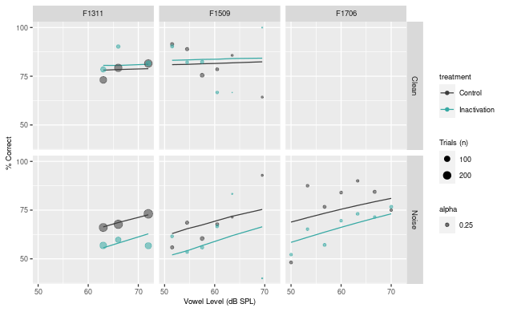

```r
ggplot(
  agg_by_level,
  aes(
    x = vowel_level,
    color = treatment
    )
  ) +
geom_line(
  aes(y = fit_p)
  ) +
geom_point(
  shape = 19,
  aes(
    y = pCorrect,
    size = nTotal,
    alpha = 0.25
    )
  ) +
scale_size(range = c(0, 4)) +
labs(
  x = "Vowel Level (dB SPL)",
  y = "% Correct",
  size='Trials (n)'
  ) +
scale_color_manual(
  labels = c("Control", "Inactivation"),
  values = c("#3d3d3d", "#37a9a4")
  ) +
  scale_x_continuous(breaks=seq(50,70,by=10)) +
  scale_y_continuous(breaks=seq(50,100,by=25)) +
theme(
  axis.text = element_text(size = 7.5),
  axis.title = element_text(size = 8),
  strip.text = element_text(size = 8),
  legend.title = element_text(size=8),
  legend.text = element_text(size=7.5)
  #strip.background = element_rect(colour="black", fill="white")
  ) +
facet_grid(
  Mask ~ fNum,
  labeller = labeller(
    Mask = c("Restricted" = "Noise", "Clean" = "Clean"),
    fNum = c("1311" = "F1311", "1509" = "F1509", "1706" = "F1706")
    )
  )


ggsave(filename = "Noise_cooling_predictions.png", width = 12, height = 6.5, units = "cm", dpi=300)
```

### 5.2. Model Checking

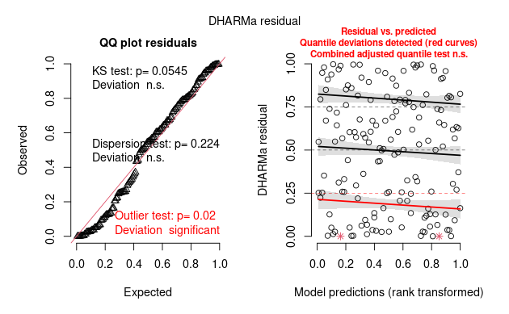

```r
simulationOutput <- simulateResiduals(fittedModel = mdl_2, n=500, plot = T)
```